# Taller 1: Estadística Descriptiva

Guía R

Edimer David Jaramillo - Bioestadística 1

Febrero de 2019

**Nota:** la base de datos utilizada para esta guía está disponible en [este enlace.](https://www.datos.gov.co/Agricultura-y-Desarrollo-Rural/Cadena-Productiva-Mango-Area-Producci-n-Y-Rendimie/yhdn-6m38)

# Manejo de datos

## ¿Cómo importar una base de datos?

**Base de datos:** Cadena Productiva del Mango en Colombia - Área, Producción y Rendimiento (2007-2017).

```r
# mango: nombre de la variable donde están almacenados los datos.
# file: archivo separado por comas (csv).
# dec: tipo de decimal (punto o coma)
mango <- read.csv(file = "Mango.csv", dec = ".")
```

## ¿Cómo identificar el tipo de variable?

```r
# str: estructura interna de la base de datos
# Character (chr) y factor: variable cualitativa o categórica
# Integer (int) y numeric (num): variable cuantitativa.
str(mango)
```

```
## 'data.frame':    2081 obs. of  16 variables:
##  $ CÓD..DEP.                                    : int  5 5 5 5 5 5 5 5 5 5 ...
##  $ DEPARTAMENTO                                 : Factor w/ 22 levels "AMAZONAS","ANTIOQUIA",..: 2 2 2 2 2 2 2 2 2 2 ...
##  $ CÓD..MUN.                                    : int  5044 5093 5001 5501 5656 5679 5042 5761 5819 5837 ...
##  $ MUNICIPIO                                    : Factor w/ 250 levels "ACANDI","ACHI",..: 14 26 123 139 190 202 207 215 228 235 ...
##  $ GRUPO.DE.CULTIVO                             : Factor w/ 1 level "FRUTALES": 1 1 1 1 1 1 1 1 1 1 ...
##  $ SUBGRUPO.DE.CULTIVO                          : Factor w/ 1 level "MANGO": 1 1 1 1 1 1 1 1 1 1 ...
##  $ CULTIVO                                      : Factor w/ 1 level "MANGO": 1 1 1 1 1 1 1 1 1 1 ...
##  $ DESAGREGACIÓN.REGIONAL.Y.O.SISTEMA.PRODUCTIVO: Factor w/ 2 levels "MANGO","MANGO INJERTO": 1 1 1 1 1 1 1 1 1 1 ...
##  $ CÓDIGO.CULTIVO                               : num  1.12e+11 1.12e+11 1.12e+11 1.12e+11 1.12e+11 ...
##  $ NOMBRE.CIENTIFICO                            : Factor w/ 1 level "MANGIFERA INDICA": 1 1 1 1 1 1 1 1 1 1 ...
##  $ PERIODO                                      : int  2007 2007 2007 2007 2007 2007 2007 2007 2007 2007 ...
##  $ Área.Sembrada.ha.                            : int  156 362 8 50 70 1116 54 186 36 250 ...
##  $ Área.Cosechada.ha.                           : int  108 274 8 50 70 1093 54 186 34 110 ...
##  $ Producción.t.                                : int  389 3836 80 600 882 5028 680 2046 134 1100 ...
##  $ Rendimiento.t.ha.                            : num  3.6 14 10 12 12.6 4.6 12.6 11 3.9 10 ...
##  $ ESTADO.FISICO.PRODUCCION                     : Factor w/ 1 level "FRUTO FRESCO": 1 1 1 1 1 1 1 1 1 1 ...
```

```r
# class: clase atómica de una variable
class(mango$Producción.t.)
```

```
## [1] "integer"
```

## ¿Cómo identificar el número de observaciones y variables?

```r
# dim: función que permite obtener las dimensiones de un arreglo.
# 2081: filas u observaciones.
# 16: columnas o variables.
dim(mango)
```

```
## [1] 2081   16
```

- **Número de filas:**

```r
# nrow: función que proporciona el número de filas.
nrow(mango)
```

```
## [1] 2081
```

- **Número de columnas:**

```r
# ncol: función que proporciona el número de columnas.
ncol(mango)
```

```
## [1] 16
```

## ¿Cómo obtener el nombre de las variables (columnas)?

```r
# names: función que proporciona el nombre de las variables
names(mango)
```

```
##  [1] "CÓD..DEP."
##  [2] "DEPARTAMENTO"
##  [3] "CÓD..MUN."
##  [4] "MUNICIPIO"
##  [5] "GRUPO.DE.CULTIVO"
##  [6] "SUBGRUPO.DE.CULTIVO"
##  [7] "CULTIVO"
##  [8] "DESAGREGACIÓN.REGIONAL.Y.O.SISTEMA.PRODUCTIVO"
##  [9] "CÓDIGO.CULTIVO"
## [10] "NOMBRE.CIENTIFICO"
## [11] "PERIODO"
## [12] "Área.Sembrada.ha."
## [13] "Área.Cosechada.ha."
## [14] "Producción.t."
## [15] "Rendimiento.t.ha."
## [16] "ESTADO.FISICO.PRODUCCION"
```

## ¿Cómo editar el nombre de las variables (columnas)?

```r
# names: también puede ser implementada para editar los nombres de una base de datos.
# c: concatenar o formar vector. En este caso se incorporan en el
#vector tantos nombres como columnas haya en la base de datos.
names(mango) <- c("cod.depto", "depto", "cod.mun", "mpio", "grupo", "subgrupo",
                  "cultivo", "tipo", "cod.cult", "cientifico", "periodo",
                  "area.semb", "area.cos", "prodn", "rto", "estado")
```

```r
# De nuevo se observan los nombres.
names(mango)
```

```
##  [1] "cod.depto"  "depto"      "cod.mun"    "mpio"       "grupo"
##  [6] "subgrupo"   "cultivo"    "tipo"       "cod.cult"   "cientifico"
## [11] "periodo"    "area.semb"  "area.cos"   "prodn"      "rto"
## [16] "estado"
```

## ¿Cómo filtrar (eliminar o seleccionar) una o más columnas de una base de datos?

- **Filtrar una columna:**

```r
# Operador "[]" para obtener subconjuntos.
# [,]: antes de la coma se indican las filas (número de fila o condicional).
# [,]: después de la coma se indican las columnas (nombre o número de columna)
# Ejempleo [1, ]: filtra la fila 1 con todas las columnas
# Ejempleo [, 1]: filtra la columna 1 con todas las filas
# Ejempleo [, -1]: filtra todas las columnas excepto la 1, con todas las filas.
# Ejempleo [c(1, 5, 10), c(1, 4, 5)]: filtra filas 1, 5 y 10 con las columnas
# 1, 4 y 5.

# mango2: nueva base de datos sin la columna número 1.
# [, -1]: todas las columnas excepto la número 1 y todas las filas.
mango2 <- mango[, -1]

# dimensiones de mango2: "mango2" tiene 15 variables, una menos que "mango"
dim(mango2)
```

```
## [1] 2081   15
```

```r
# filtrar una columna por nombre
mango2.1 <- mango[, "depto"]
```

- **Filtrar dos o más columnas:**

```r
# Filtrar las siguientes columnas:
# Departamento - (Posición número 2).
# Tipo: injerto o normal - (Posición número 8).
# Período: años - (Posición número 11).
# Área sembrada - (Posición número 12).
# Área cosechada - (Posición número 13).
# Producción - (Posición número 14).
# Rendimiento - (Posición número 15).

# Filtro por nombre de variable en "mango3"
mango3 <- mango[, c("depto", "tipo", "periodo", "area.semb", "area.cos",
                    "prodn", "rto")]

# La nueva base de datos sólo tiene las variables indicadas en "mango3"
# head: imprime en pantalla sólo las primeras 6 observaciones de una base de datos
head(mango3)
```

|  | depto | tipo | periodo | area.semb | area.cos | prodn | rto |
| --- | --- | --- | --- | --- | --- | --- | --- |
| 1 | ANTIOQUIA | MANGO | 2007 | 156 | 108 | 389 | 3.6 |
| 2 | ANTIOQUIA | MANGO | 2007 | 362 | 274 | 3836 | 14.0 |
| 3 | ANTIOQUIA | MANGO | 2007 | 8 | 8 | 80 | 10.0 |
| 4 | ANTIOQUIA | MANGO | 2007 | 50 | 50 | 600 | 12.0 |
| 5 | ANTIOQUIA | MANGO | 2007 | 70 | 70 | 882 | 12.6 |
| 6 | ANTIOQUIA | MANGO | 2007 | 1116 | 1093 | 5028 | 4.6 |

```r
# Filtro por posición de la variable
mango4 <- mango[, c(2, 8, 11:15)]

# "mango3" y "mango4" son exactamente iguales
head(mango4)
```

|  | depto | tipo | periodo | area.semb | area.cos | prodn | rto |
| --- | --- | --- | --- | --- | --- | --- | --- |
| 1 | ANTIOQUIA | MANGO | 2007 | 156 | 108 | 389 | 3.6 |
| 2 | ANTIOQUIA | MANGO | 2007 | 362 | 274 | 3836 | 14.0 |
| 3 | ANTIOQUIA | MANGO | 2007 | 8 | 8 | 80 | 10.0 |
| 4 | ANTIOQUIA | MANGO | 2007 | 50 | 50 | 600 | 12.0 |
| 5 | ANTIOQUIA | MANGO | 2007 | 70 | 70 | 882 | 12.6 |
| 6 | ANTIOQUIA | MANGO | 2007 | 1116 | 1093 | 5028 | 4.6 |

## ¿Cómo filtrar una fila u observación de una base de datos?

- **Filtrar de “mango4” o “mango3” áreas sembradas máximo de 1000 hectáreas:**

```r
# <: menor
# >: mayor
# <=: menor o igual
# >=: mayor o igual
# ==: igual
# !=: diferente

mango5 <- mango4[mango4$area.semb <= 1000, ]
```

- **Filtrar de “mango5” sólo información de Antioquia o Tolima:**

```r
# &: y
# |: o
mango6 <- mango5[mango5$depto == "ANTIOQUIA" | mango5$depto == "TOLIMA", ]
head(mango6)
```

|  | depto | tipo | periodo | area.semb | area.cos | prodn | rto |
| --- | --- | --- | --- | --- | --- | --- | --- |
| 1 | ANTIOQUIA | MANGO | 2007 | 156 | 108 | 389 | 3.6 |
| 2 | ANTIOQUIA | MANGO | 2007 | 362 | 274 | 3836 | 14.0 |
| 3 | ANTIOQUIA | MANGO | 2007 | 8 | 8 | 80 | 10.0 |
| 4 | ANTIOQUIA | MANGO | 2007 | 50 | 50 | 600 | 12.0 |
| 5 | ANTIOQUIA | MANGO | 2007 | 70 | 70 | 882 | 12.6 |
| 7 | ANTIOQUIA | MANGO | 2007 | 54 | 54 | 680 | 12.6 |

```r
# tail: muestra las últimas 6 observaciones de la base de datos
tail(mango6)
```

|  | depto | tipo | periodo | area.semb | area.cos | prodn | rto |
| --- | --- | --- | --- | --- | --- | --- | --- |
| 2039 | ANTIOQUIA | MANGO INJERTO | 2013 | 3 | 3 | 9 | 3.0 |
| 2042 | TOLIMA | MANGO | 2017 | 59 | 59 | 749 | 12.7 |
| 2044 | ANTIOQUIA | MANGO INJERTO | 2016 | 531 | 108 | 1372 | 12.7 |
| 2057 | ANTIOQUIA | MANGO INJERTO | 2015 | 2 | 2 | 5 | 2.5 |
| 2061 | TOLIMA | MANGO | 2015 | 45 | 30 | 270 | 9.0 |
| 2075 | ANTIOQUIA | MANGO INJERTO | 2014 | 26 | 25 | 100 | 4.0 |

- **Filtrar de “mango6” información del año 2017 y rendimientos mayores a 20 t/ha:**

```r
mango6.1 <- mango6[mango6$periodo == 2017 & mango6$rto > 20, ]
mango6.1
```

|  | depto | tipo | periodo | area.semb | area.cos | prodn | rto |
| --- | --- | --- | --- | --- | --- | --- | --- |
| 1635 | TOLIMA | MANGO | 2017 | 38 | 33 | 697 | 21.2 |
| 1679 | TOLIMA | MANGO | 2017 | 351 | 312 | 8336 | 26.7 |
| 1683 | ANTIOQUIA | MANGO INJERTO | 2017 | 3 | 3 | 55 | 22.0 |
| 1773 | TOLIMA | MANGO | 2017 | 21 | 12 | 358 | 30.8 |

### Filtro con `subset()`

- **Filtrar filas del año 2017 y rendimiento mayores a 20 t/ha sin la variable departamento:**

```r
# subset: función que permite filtrar filas y columnas
# x: base de datos
# subset: filtro de filas
# select: filtro de columnas
mango6.2 <- subset(x = mango6, subset = periodo == 2017 & rto > 20,
                   select = -depto)
head(mango6.2)
```

|  | tipo | periodo | area.semb | area.cos | prodn | rto |
| --- | --- | --- | --- | --- | --- | --- |
| 1635 | MANGO | 2017 | 38 | 33 | 697 | 21.2 |
| 1679 | MANGO | 2017 | 351 | 312 | 8336 | 26.7 |
| 1683 | MANGO INJERTO | 2017 | 3 | 3 | 55 | 22.0 |
| 1773 | MANGO | 2017 | 21 | 12 | 358 | 30.8 |

## ¿Cómo obtener una sumatoria?

```r
# sum: función para sumatorias
sum(mango6$prodn)
```

```
## [1] 441396
```

- **Total de toneladas de mango producidas por departamento entre 2007 y 2017:**

```r
# X: variable numérica
# INDEX: variable categórica (factor)
# FUN: función a ejecutar

tapply(X = mango5$prodn, INDEX = mango5$depto, FUN = sum)
```

```
##           AMAZONAS          ANTIOQUIA          ATLANTICO
##               1876             104713             148792
##            BOLIVAR             BOYACA             CALDAS
##             179661               2734               9919
##           CASANARE              CAUCA              CESAR
##                374              26890              78032
##              CHOCO            CORDOBA       CUNDINAMARCA
##                  0             111028             411419
##              HUILA         LA GUAJIRA          MAGDALENA
##              16947              16516             242289
##             NARIÑO NORTE DE SANTANDER          SANTANDER
##               5544               2029               6311
##              SUCRE             TOLIMA    VALLE DEL CAUCA
##               9294             336683              12777
##            VICHADA
##               4750
```

## ¿Cómo obtener una nueva variable con datos ya existentes?

- **Recalculando el rendimiento (producción/área cosechada):**

```r
# Nueva variable "rto2" con el operador "$"
mango5$rto2 <- mango5$prodn/mango5$area.cos
head(mango5)
```

|  | depto | tipo | periodo | area.semb | area.cos | prodn | rto | rto2 |
| --- | --- | --- | --- | --- | --- | --- | --- | --- |
| 1 | ANTIOQUIA | MANGO | 2007 | 156 | 108 | 389 | 3.6 | 3.601852 |
| 2 | ANTIOQUIA | MANGO | 2007 | 362 | 274 | 3836 | 14.0 | 14.000000 |
| 3 | ANTIOQUIA | MANGO | 2007 | 8 | 8 | 80 | 10.0 | 10.000000 |
| 4 | ANTIOQUIA | MANGO | 2007 | 50 | 50 | 600 | 12.0 | 12.000000 |
| 5 | ANTIOQUIA | MANGO | 2007 | 70 | 70 | 882 | 12.6 | 12.600000 |
| 7 | ANTIOQUIA | MANGO | 2007 | 54 | 54 | 680 | 12.6 | 12.592593 |

## ¿Cómo redondear un número?

```r
# round: función para redondear números
# x: número o vector de números
# digits: número de dígitos para redondear
round(x = 2.1678,  digits = 2)
```

```
## [1] 2.17
```

- **Redondeando “rto2” con un dígito:**

```r
mango5$rto2 <- round(x = mango5$rto2, digits = 1)
head(mango5)
```

|  | depto | tipo | periodo | area.semb | area.cos | prodn | rto | rto2 |
| --- | --- | --- | --- | --- | --- | --- | --- | --- |
| 1 | ANTIOQUIA | MANGO | 2007 | 156 | 108 | 389 | 3.6 | 3.6 |
| 2 | ANTIOQUIA | MANGO | 2007 | 362 | 274 | 3836 | 14.0 | 14.0 |
| 3 | ANTIOQUIA | MANGO | 2007 | 8 | 8 | 80 | 10.0 | 10.0 |
| 4 | ANTIOQUIA | MANGO | 2007 | 50 | 50 | 600 | 12.0 | 12.0 |
| 5 | ANTIOQUIA | MANGO | 2007 | 70 | 70 | 882 | 12.6 | 12.6 |
| 7 | ANTIOQUIA | MANGO | 2007 | 54 | 54 | 680 | 12.6 | 12.6 |

## ¿Cuáles son las categorías o niveles de una variable cualitativa (factor)?

```r
levels(mango5$depto)
```

```
##  [1] "AMAZONAS"           "ANTIOQUIA"          "ATLANTICO"
##  [4] "BOLIVAR"            "BOYACA"             "CALDAS"
##  [7] "CASANARE"           "CAUCA"              "CESAR"
## [10] "CHOCO"              "CORDOBA"            "CUNDINAMARCA"
## [13] "HUILA"              "LA GUAJIRA"         "MAGDALENA"
## [16] "NARIÑO"             "NORTE DE SANTANDER" "SANTANDER"
## [19] "SUCRE"              "TOLIMA"             "VALLE DEL CAUCA"
## [22] "VICHADA"
```

# Gráficos

## ¿Cómo agregar una línea (horizontal o vertical) a un gráfico?

- **Distribución del rendimiento (t/ha) de mango:**

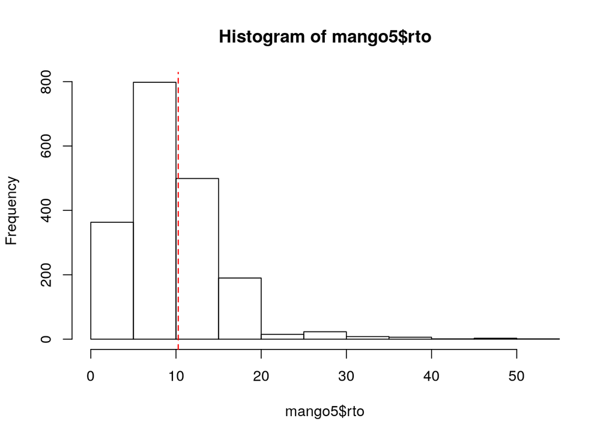

```r
# abline: función que permite añadir líneas a un gráfico
# v: línea vertical
# lwd: ancho de línea
# col: color de línea
# lty: tipo de línea (2 = punteada)
# mean: función para obtener la media
# mean(mango5$rto, na.rm = TRUE): na.rm = TRUE permite calcular la media aún cuando
# existen valores ausentes (vacios o en blanco).

hist(mango5$rto)
abline(v = mean(mango5$rto, na.rm = TRUE), lwd = 1.3, col = "red", lty = 2)
```

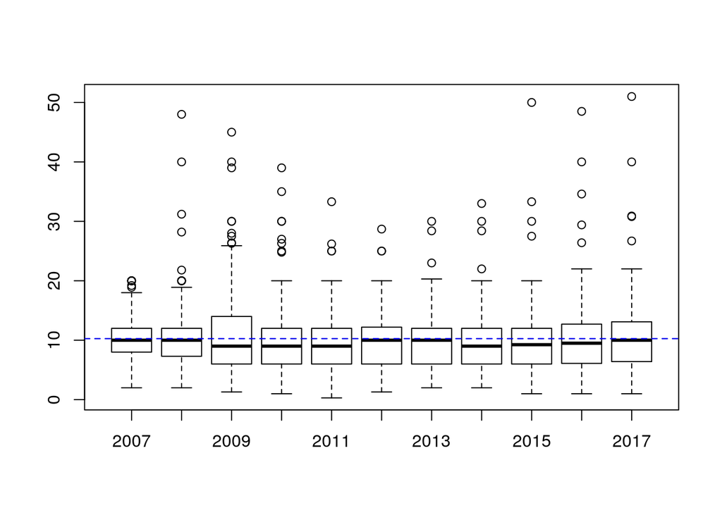

```r
# abline: función que permite añadir líneas a un gráfico
# h: línea horizontal

boxplot(mango5$rto ~ mango5$periodo)
abline(h = mean(mango5$rto, na.rm = TRUE), lwd = 1.2, col = "blue2", lty = 2)
```

## ¿Cómo rotar las etiquetas del eje X?

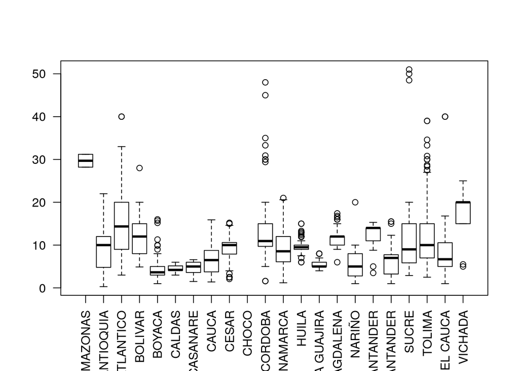

```r
# Horizontal: las = 1
# Vertical: las = 2

boxplot(mango5$rto ~ mango5$depto, las = 2)
```

## ¿Cómo editar márgenes de un gráfico?

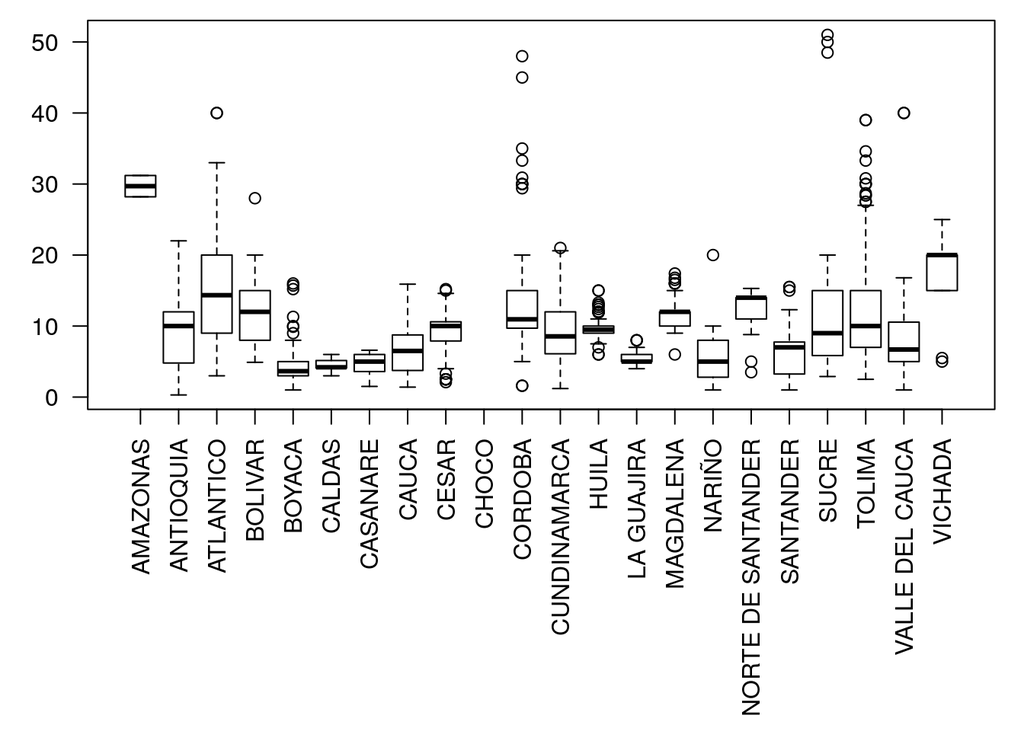

```r
# par: función para editar parámetros gráficos
# mar: edición de márgenes del gráfico
# mar = c(abajo, izquierda, arriba, derecha)
# margen inferior: 11
# margen izquierda: 3
# margen superior: 0.7
# margen derecha: 1

boxplot(mango5$rto ~ mango5$depto, las = 2, par(mar = c(11, 3, 0.7, 1)))
```

## ¿Cómo construir un boxplot horizontal?

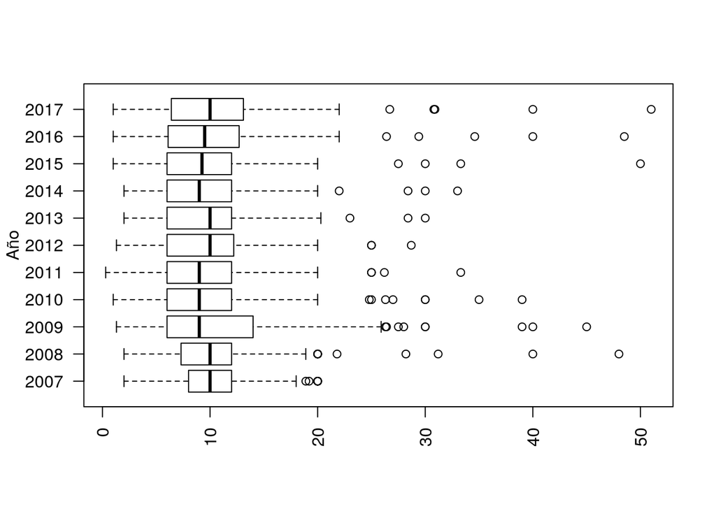

```r
# horizontal = TRUE: gráfico horizontal
# horizontal = FALSE: gráfico vertical o normal

boxplot(mango5$rto ~ mango5$periodo, horizontal = TRUE, las = 2,
        ylab = "Año")
```

## ¿Cómo agregar puntos (medidas estadísticas) a un gráfico?

-**Puntos representando el promedio de rendimiento en cada año:**

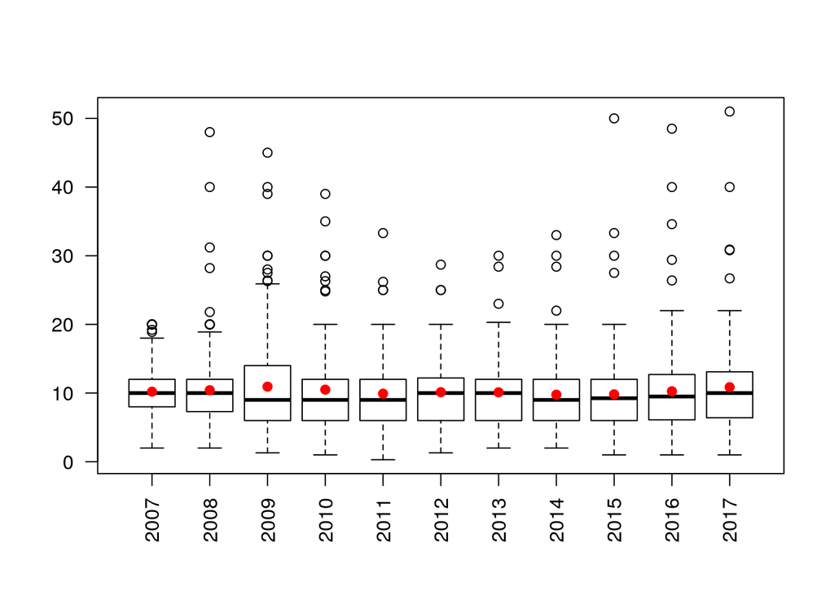

```r
# points: función para adicioanr puntos a un gráfico
# tapply: función para operar por grupos (factores)
# pch = tipo de punto
# col: color del punto
# cex: tamaño del punto
# na.rm = TRUE: posibilita calcular la media en presencia de celdas vacías

boxplot(mango5$rto ~ mango5$periodo, las = 2)
points(tapply(X = mango5$rto, INDEX = mango5$periodo, FUN = mean,
              na.rm = TRUE), pch = 19, col = "red", cex = 1)
```

## ¿Cómo agregar líneas (tendencia) a un gráfico?

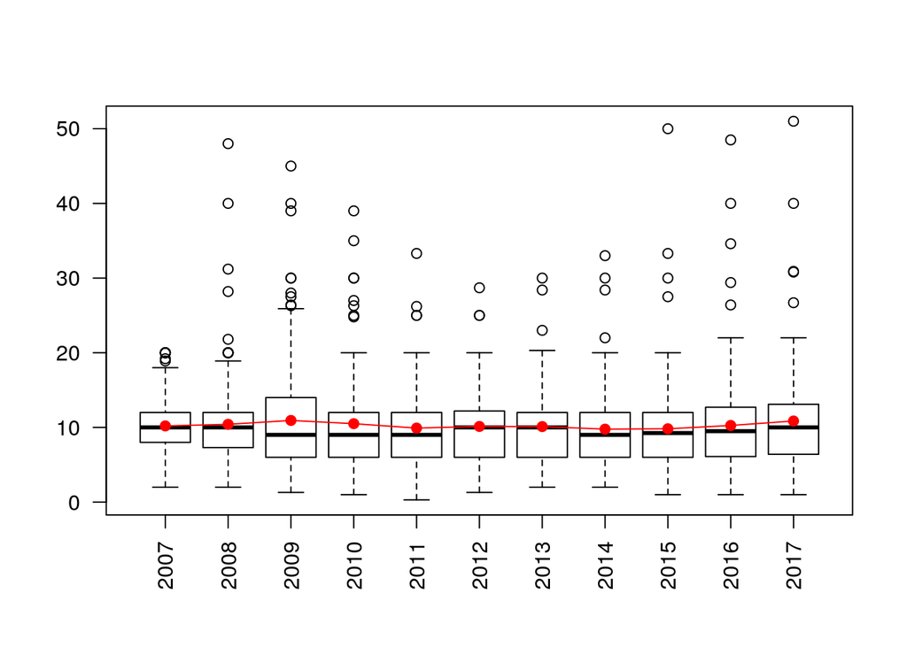

```r
# lines: agregar línea a un gráfico
# lwd = ancho de línea

boxplot(mango5$rto ~ mango5$periodo, las = 2)
points(tapply(X = mango5$rto, INDEX = mango5$periodo, FUN = mean,
              na.rm = TRUE), pch = 19, col = "red", cex = 1)
lines(tapply(X = mango5$rto, INDEX = mango5$periodo, FUN = mean,
              na.rm = TRUE), col = "red", lwd = 1)
```

## ¿Cómo agregar etiquetas (leyenda) a un gráfico?

- **Relación de área sembrada vs rendimiento:**

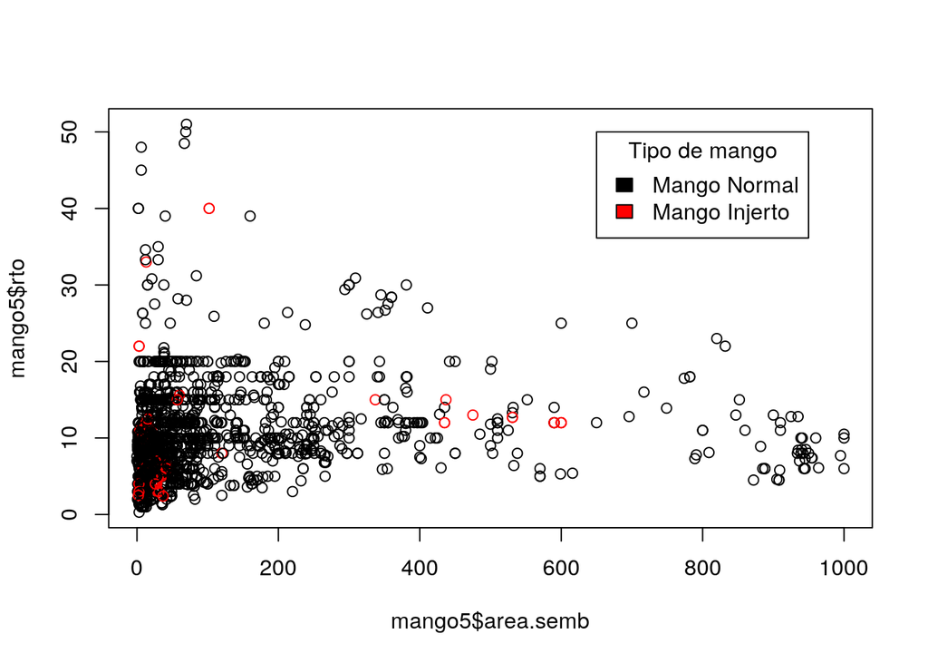

```r
# legend: permite incorporar etiquetas de guía a un gráfico
# x = 650: ubicación de la leyenda en el eje x
# y = 50: ubicación de la leyenda en el eje y
# legend = c(...): nombres de etiquetas
# fill: color de los puntos de la etiqueta
# title: título de la leyenda

plot(x = mango5$area.semb, y = mango5$rto, col = mango5$tipo)
legend(x = 650, y = 50, legend = c("Mango Normal", "Mango Injerto"),
       fill = c("black", "red"), title = "Tipo de mango")
```

## Diagramas de barras para representar promedio y desviación estándar

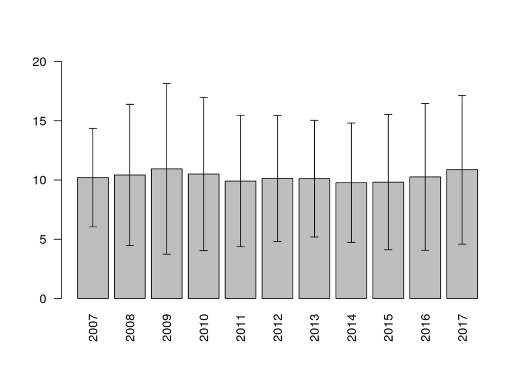

```r
# medias: medias por tipo de mango
# desvios: desviación estándar por tipo de mango
# g1: gráfico de barras
# arrows: permite añadir flechas a un gráfico

medias <- tapply(mango5$rto, mango5$periodo, mean, na.rm = TRUE)
desvios <- tapply(mango5$rto, mango5$periodo, sd, na.rm = TRUE)

g1 <- barplot(medias, las = 2, ylim = c(0, 20))
arrows(x0 = g1, y0 = medias + desvios, y1 = medias - desvios, angle = 90, code = 3,
       length = 0.05)
```